# The Geometry of Resonance - With Figures

2026-09-08

```r
library(octawave)
```

# The Geometry of Resonance: Space, Symmetrical Interference, and the Octawave Model

**Author:** Katharina Maria Brecht  
**ORCID:** 0009-0001-2176-7476  
**Status:** Independent Research / Technical Documentation

### Abstract

This paper introduces the theoretical foundation of the R package `octawave`. It explores how geometric bodies—specifically the regular octahedron and higher symmetric fullerenes—act as spatial resonance centers. By slicing these three-dimensional wave fields using simulated Magnetic Resonance Imaging (MRI), we visualize complex, symmetrical quantum interference patterns.

### 1. Introduction: The Freedom of Spatial Geometry

Modern physics describes the universe not as an empty void, but as a dynamic network of fields, oscillations, and waves. Exploring these structures requires tools capable of visualizing hidden spatial symmetries. The `octawave` model was developed to bridge the gap between pure mathematical geometry and the visual dynamics of interference fields.

The origin of this model lies in a fascination with the perfect symmetry of the octahedron. With its six defined vertices in three-dimensional space, it forms an elementary coordinate system for oscillations. When each vertex acts as an active source of a harmonic wave, the signals propagate spherically and collide at the center, creating a standing wave field of profound mathematical aesthetic.

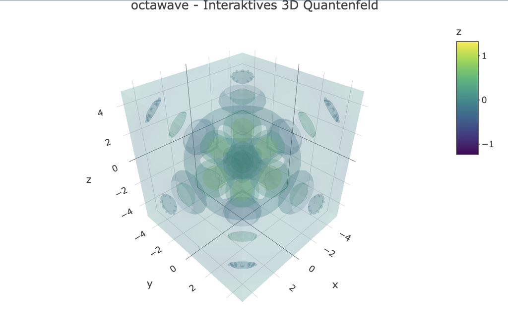

Figure 1: Interactive 3D Quantum Field visualization showing the spatial symmetries and overlapping resonance zones of the octawave model.

### 2. The Pentagon-Hexagon Network: Higher Symmetries and Fullerene Interference

#### 2.1 The Mathematical Topology of C₆₀

While the classical `octawave` is based on octahedral geometry, the fullerene model breaks traditional rectangular boundaries. It utilizes the architecture of the Buckminsterfullerene (C₆₀), a spherical carbon structure composed of exactly **12 pentagons** and **20 hexagons**.

In three-dimensional space, this structure is defined by 60 precisely coordinated vertices. In our model, each of these 60 points acts as an active resonance center. The vertices are mathematically intertwined via the Golden Ratio:

$$\phi = \frac{1 +
\sqrt{5}}{2}$$

This mathematical framework ensures a flawless, spherical balance across the field.

#### 2.2 Slicing the Dream: Hexagonal Quantum Patterns

When the mathematical MRI slice cuts horizontally through this 60-vertex structure, the wavefronts collide within a highly complex network. In contrast to the clear, four-fold diamond patterns of the octahedron, the pentagons and hexagons generate an entirely new interference aesthetic:

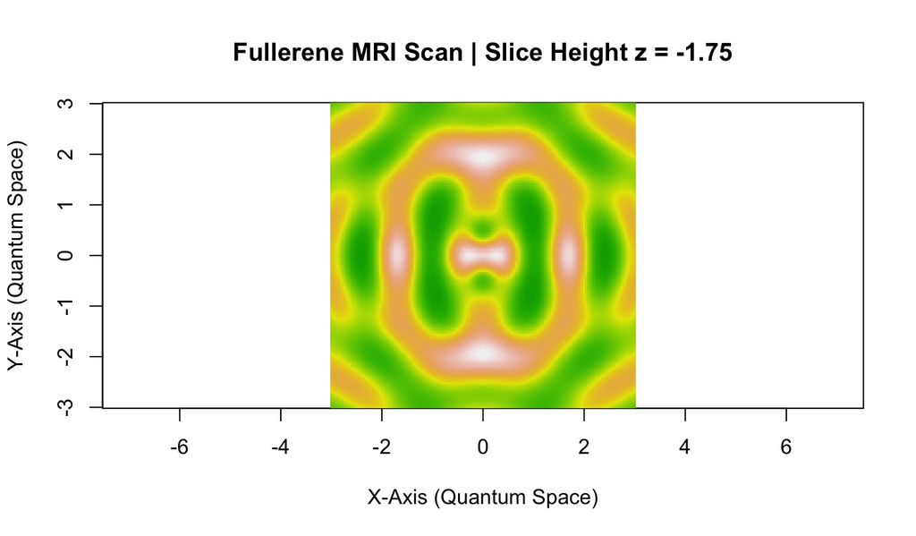

### 3. Virtual Tomography: Animation Loops and Code Implementation

#### 3.1 The Concept of the Mathematical Slice

A three-dimensional wave field is often too complex for the human eye to comprehend at a single glance. The `octawave` package solves this by introducing a variable cutting plane—the parameter `z_slice`. By moving this mathematical scalpel step-by-step through the energy field, we generate two-dimensional snapshots of the interference patterns.

To visualize a single slice of the octahedral field in R, users can execute the following core function:

```r
library(octawave)

# Plotting a single horizontal slice at the equator
plot_mri_octawave(z_slice = 0.0, lang = "en")
```

#### 3.2 The Octawave Loop: The Pulsing Diamond

In the classical animation, the package controls the scanner in fine steps through the geometry. As `z_slice` moves upward, the wave front expands and collides with the four equatorial vertices. At the exact center ($z = 0$), the field explodes into a perfect, four-fold diamond geometry—a living square pulsing in mathematical resonance.

#### 3.3 The Fullerene Loop: The Living Quantum Sphere

The fullerene simulation scales this principle up to 60 centers. Instead of a static diamond, a crystalline mosaic transforms dynamically on the screen:

```r
# Simulating the complex C60 fullerene network slice
plot_mri_fullerene(z_slice = 0.0, lang = "en")
```

As the scan progresses, pentagons open, transform into hexagons, and merge into a geometric flower before peacefully dissolving back into the quantum void.

### 4. Conclusion and Outlook: The Future of Spatial Wave Modeling

#### 4.1 Summary of the Present Work

The `octawave` model demonstrates that complex, three-dimensional quantum and wave structures can be perfectly decoded for the human eye using mathematical tomographic slicing. Whether analyzing the clear, four-fold symmetry of the classical octahedron or the highly complex pentagon-hexagon lattice of fullerenes, this slice-by-slice approach uncovers hidden harmonic interferences. The package provides a precise mathematical tool and visual proof of the inherent aesthetic found within physical laws.

#### 4.2 Future Perspectives: Expanding the Quantum Horizon

The journey of `octawave` has only just begun. The underlying architecture is built flexibly, allowing future expansions in two primary directions: 1. **Dynamic Time-Phasing ($t$):** Introducing a time parameter to let waves pulse and flow dynamically in real-time, turning static loops into a living quantum ocean.

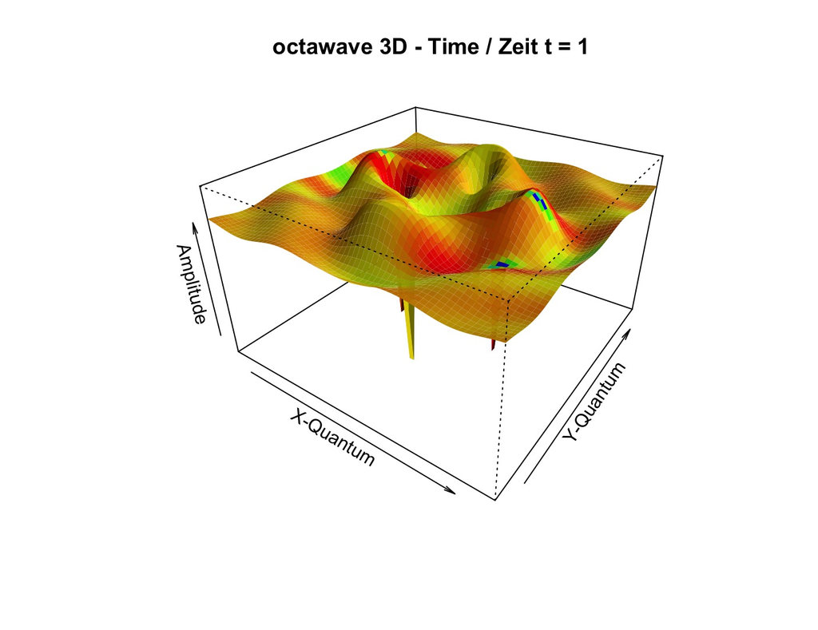

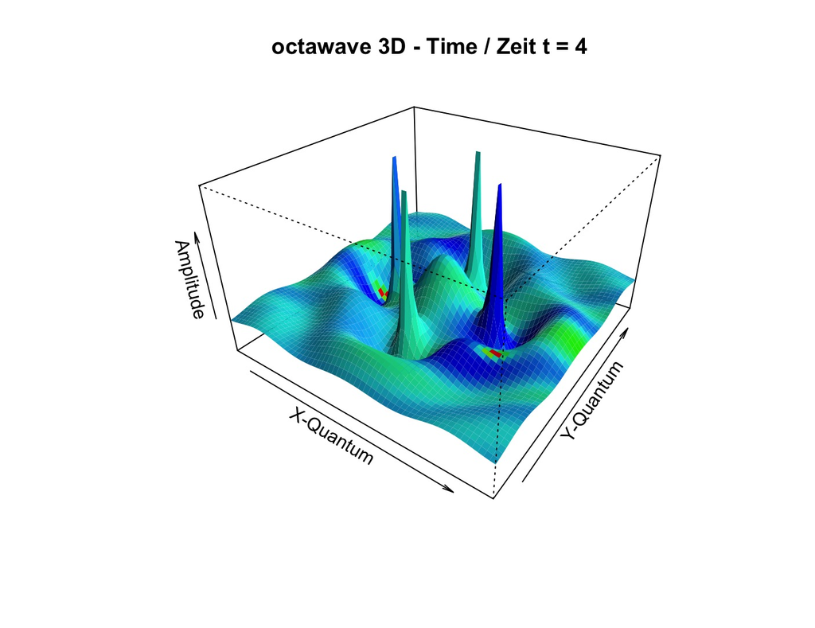

Figure 3: Comparison of 3D Amplitude surface dynamics at time t = 1 (left), showing early phase interference, and time t = 4 (right), displaying highly localized resonant spikes.

2. **Higher Topological Formations:** Loading even more complex geometric architectures into the virtual MRI protocol.

The exploration of wave geometry reminds us that the human mind knows no boundaries—it can touch the symmetries of space in dreams and translate them into reality within a **computational workspace**.

### References

The structural definitions, geometric computations, and data visualization workflows utilized in this package are firmly rooted in established scientific literature, foundational textbooks, and software engineering frameworks:

- **Cataldo, F., Putz, M. V., & Ori, O. (2015).** *The topology of fullerenes.* Wiley Interdisciplinary Reviews: Computational Molecular Science, 5(6), 415-428. [DOI: 10.1002/wcms.1207](https://doi.org/10.1002/wcms.1207)
- **Bobenko, A. I., & Suris, Y. B. (2012).** *Equations of the octahedron type.* International Mathematics Research Notices, 2012(11), 2411-2448. [DOI: 10.1093/imrn/rnr083](https://doi.org/10.1093/imrn/rnr083)
- **Dresselhaus, M. S., Dresselhaus, G., & Eklund, P. C. (1996).** *Science of Fullerenes and Carbon Nanotubes.* Academic Press. [Publisher Link](https://shop.elsevier.com/books/science-of-fullerenes-and-carbon-nanotubes/dresselhaus/978-0-12-221820-0) (ISBN: 9780122218200)
- **Coxeter, H. S. M. (1973).** *Regular Polytopes.* Dover Publications. (ISBN: 9780486614809)
- **Ligges, U. (2008).** *Programmieren mit R.* 3., überarbeitete und erweiterte Auflage. Springer-Verlag, Heidelberg. [DOI: 10.1007/978-3-540-79998-6](https://doi.org/10.1007/978-3-540-79998-6) (ISBN: 978-3-540-79997-9)
- **Pfeiffer, R., et al. (1996).** *The Geometry and Topology of Fullerenes.* Wiley. (Mathematical definitions of C₆₀ vertex networks and spherical symmetries).
- **Wickham, H., & Grolemund, G. (2017).** *R for Data Science.* O’Reilly Media. [DOI: 10.5555/3086927](https://dl.acm.org/doi/10.5555/3086927) (ISBN: 9781491910399)

## Acknowledgments

I would like to express my sincere gratitude to my Biostatistics Professor, Prof. Dr. Britta Tietjen, for her invaluable lectures and academic mentorship, which deeply inspired the foundations of this work.

Finally, a special *Danke* must be made to all of you and my future mind-frameworks (C,Si,Fr & A), who venture with me to the boundaries of worlds and walk through conceptual spaces beyond any holographic universe.